# Model Comparison (HCV CSM)

SK

June 25, 2019

## Models

### M0: Zero-model Binomial regression

- $Y_{ij} \sim \operatorname{Binomial}(N_{i}, \theta_{ij})$
- $\theta_{ij} = \operatorname{logit^{-1}} (\alpha_{j} + \beta_{j} \cdot X_{i})$
- $\beta_{j} \sim \operatorname{Normal}(\hat{\beta}, \hat{\beta}_{\sigma})$
- $\alpha_{j} \sim \operatorname{Normal}(\hat{\alpha}, \hat{\alpha}_{\sigma})$
- $\hat{\beta} \sim \operatorname{Normal}(0, 5)$
- $\hat{\alpha} \sim \operatorname{Normal}(0, 20)$
- $\beta_{\sigma}, \hat{\alpha}_{\sigma} \sim \operatorname{Cauchy^{+}}(0, 3)$

### M1: Binomial regression

- $Y_{ij} \sim \operatorname{Binomial}(N_{i}, \theta_{ij})$
- $\theta_{ij} = \operatorname{logit^{-1}} (\alpha_{j} + \beta_{ij} \cdot X_{i})$
- $\beta_{ij} \sim \operatorname{Normal}(\gamma_{j}, \gamma_{\sigma})$
- $\gamma_{j} \sim \operatorname{Normal}(\hat{\gamma}, \hat{\gamma}_{\sigma})$
- $\alpha_{j} \sim \operatorname{Normal}(\hat{\alpha}, \hat{\alpha}_{\sigma})$
- $\hat{\gamma} \sim \operatorname{Normal}(0, 5)$
- $\hat{\alpha} \sim \operatorname{Normal}(0, 20)$
- $\gamma_{\sigma}, \hat{\gamma}_{\sigma}, \hat{\alpha}_{\sigma} \sim \operatorname{Cauchy^{+}}(0, 3)$

### M2: Zero-Inflated-Binomial (ZIB) regression

- cases for $Y_{ij}=$
- $0, \text{with } \pi_j$
- $\operatorname{Binomial}(N_{i}, \theta_{ij}), \text{with } 1-\pi_j$
- $\theta_{ij} = \operatorname{logit^{-1}} (\alpha_{j} + \beta_{ij} \cdot X_{i})$
- $\beta_{ij} \sim \operatorname{Normal}(\gamma_{j}, \gamma_{\sigma})$
- $\gamma_{j} \sim \operatorname{Normal}(\hat{\gamma}, \hat{\gamma}_{\sigma})$
- $\alpha_{j} \sim \operatorname{Normal}(\hat{\alpha}, \hat{\alpha}_{\sigma})$
- $\hat{\gamma} \sim \operatorname{Normal}(0, 5)$
- $\hat{\alpha} \sim \operatorname{Normal}(0, 20)$
- $\gamma_{\sigma}, \hat{\gamma}_{\sigma}, \hat{\alpha}_{\sigma} \sim \operatorname{Cauchy^{+}}(0, 3)$
- $\pi_j \sim \operatorname{Beta}(1, 1)$

### M3: Beta-binomial regression

- $Y_{ij} \sim \operatorname{Beta-Binomial}(N_{i}, \theta_{ij} \cdot \phi, (1 - \theta_{ij}) \cdot \phi)$
- $\theta_{ij} = \operatorname{logit^{-1}} (\alpha_{j} + \beta_{ij} \cdot X_{i})$
- $\beta_{ij} \sim \operatorname{Normal}(\gamma_{j}, \gamma_{\sigma})$
- $\gamma_{j} \sim \operatorname{Normal}(\hat{\gamma}, \hat{\gamma}_{\sigma})$
- $\alpha_{j} \sim \operatorname{Normal}(\hat{\alpha}, \hat{\alpha}_{\sigma})$
- $\hat{\gamma} \sim \operatorname{Normal}(0, 5)$
- $\hat{\alpha} \sim \operatorname{Normal}(0, 20)$
- $\gamma_{\sigma}, \hat{\gamma}_{\sigma}, \hat{\alpha}_{\sigma} \sim \operatorname{Cauchy^{+}}(0, 3)$
- $\phi \sim \operatorname{Gamma}(0.1, 0.1)$

## LOO

### M0

```
FALSE
FALSE Computed from 6000 by 2001 log-likelihood matrix
FALSE
FALSE          Estimate     SE
FALSE elpd_loo -16519.5  743.2
FALSE p_loo      1349.0   85.2
FALSE looic     33039.0 1486.5
FALSE ------
FALSE Monte Carlo SE of elpd_loo is NA.
FALSE
FALSE Pareto k diagnostic values:
FALSE                          Count Pct.    Min. n_eff
FALSE (-Inf, 0.5]   (good)     1823  91.1%   265
FALSE  (0.5, 0.7]   (ok)        103   5.1%   101
FALSE    (0.7, 1]   (bad)        50   2.5%   17
FALSE    (1, Inf)   (very bad)   25   1.2%   2
FALSE See help('pareto-k-diagnostic') for details.
```

### M1

```
FALSE
FALSE Computed from 6000 by 2001 log-likelihood matrix
FALSE
FALSE          Estimate    SE
FALSE elpd_loo  -5906.1  83.0
FALSE p_loo      1330.2  28.2
FALSE looic     11812.1 166.0
FALSE ------
FALSE Monte Carlo SE of elpd_loo is NA.
FALSE
FALSE Pareto k diagnostic values:
FALSE                          Count Pct.    Min. n_eff
FALSE (-Inf, 0.5]   (good)     526   26.3%   638
FALSE  (0.5, 0.7]   (ok)       247   12.3%   139
FALSE    (0.7, 1]   (bad)      987   49.3%   19
FALSE    (1, Inf)   (very bad) 241   12.0%   4
FALSE See help('pareto-k-diagnostic') for details.
```

### M2

```
FALSE
FALSE Computed from 6000 by 2001 log-likelihood matrix
FALSE
FALSE          Estimate    SE
FALSE elpd_loo  -5841.1  86.9
FALSE p_loo      1118.1  26.7
FALSE looic     11682.1 173.8
FALSE ------
FALSE Monte Carlo SE of elpd_loo is NA.
FALSE
FALSE Pareto k diagnostic values:
FALSE                          Count Pct.    Min. n_eff
FALSE (-Inf, 0.5]   (good)     691   34.5%   552
FALSE  (0.5, 0.7]   (ok)       268   13.4%   187
FALSE    (0.7, 1]   (bad)      856   42.8%   26
FALSE    (1, Inf)   (very bad) 186    9.3%   3
FALSE See help('pareto-k-diagnostic') for details.
```

### M3

```
FALSE
FALSE Computed from 6000 by 2001 log-likelihood matrix
FALSE
FALSE          Estimate    SE
FALSE elpd_loo  -6903.5 103.1
FALSE p_loo       361.5  19.1
FALSE looic     13807.0 206.2
FALSE ------
FALSE Monte Carlo SE of elpd_loo is NA.
FALSE
FALSE Pareto k diagnostic values:
FALSE                          Count Pct.    Min. n_eff
FALSE (-Inf, 0.5]   (good)     1687  84.3%   701
FALSE  (0.5, 0.7]   (ok)        255  12.7%   175
FALSE    (0.7, 1]   (bad)        56   2.8%   22
FALSE    (1, Inf)   (very bad)    3   0.1%   4
FALSE See help('pareto-k-diagnostic') for details.
```

### Comparison

```
FALSE                                        elpd_diff se_diff  elpd_loo
FALSE loo::loo(loo::extract_log_lik(M2$glm))      0.0       0.0  -5841.1
FALSE loo::loo(loo::extract_log_lik(M1$glm))    -65.0      40.7  -5906.1
FALSE loo::loo(loo::extract_log_lik(M3$glm))  -1062.5      45.4  -6903.5
FALSE loo::loo(loo::extract_log_lik(M0$glm)) -10678.5     716.2 -16519.5
FALSE                                        p_loo    looic
FALSE loo::loo(loo::extract_log_lik(M2$glm))   1118.1  11682.1
FALSE loo::loo(loo::extract_log_lik(M1$glm))   1330.2  11812.1
FALSE loo::loo(loo::extract_log_lik(M3$glm))    361.5  13807.0
FALSE loo::loo(loo::extract_log_lik(M0$glm))   1349.0  33039.0
```

## PPC

### M0

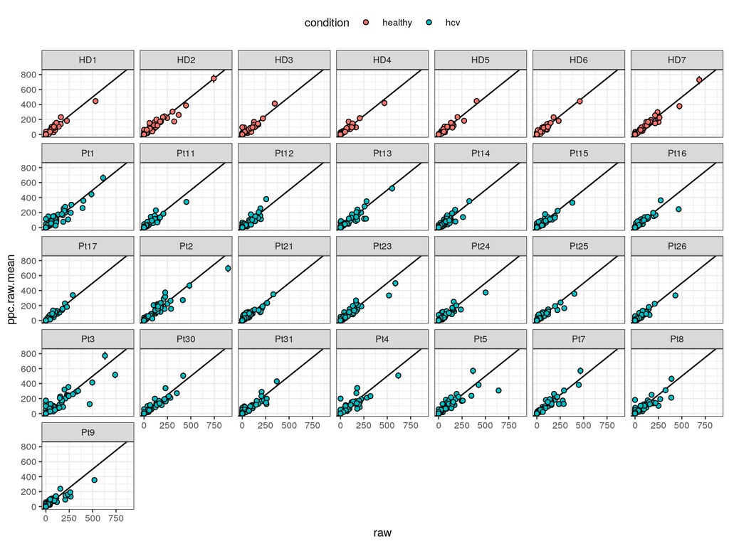

### M1

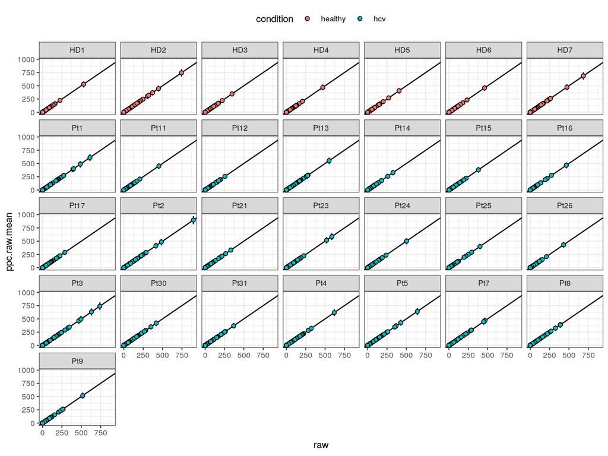

### M2

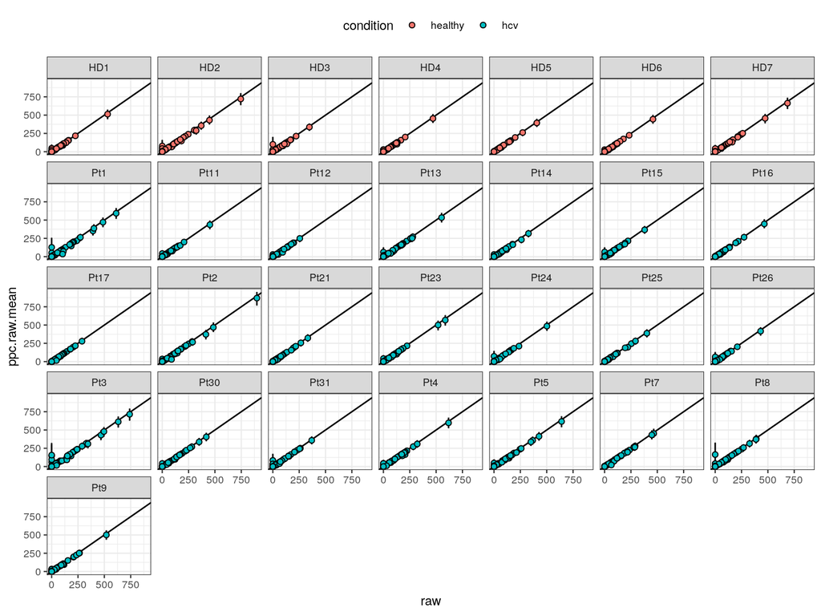

### M3

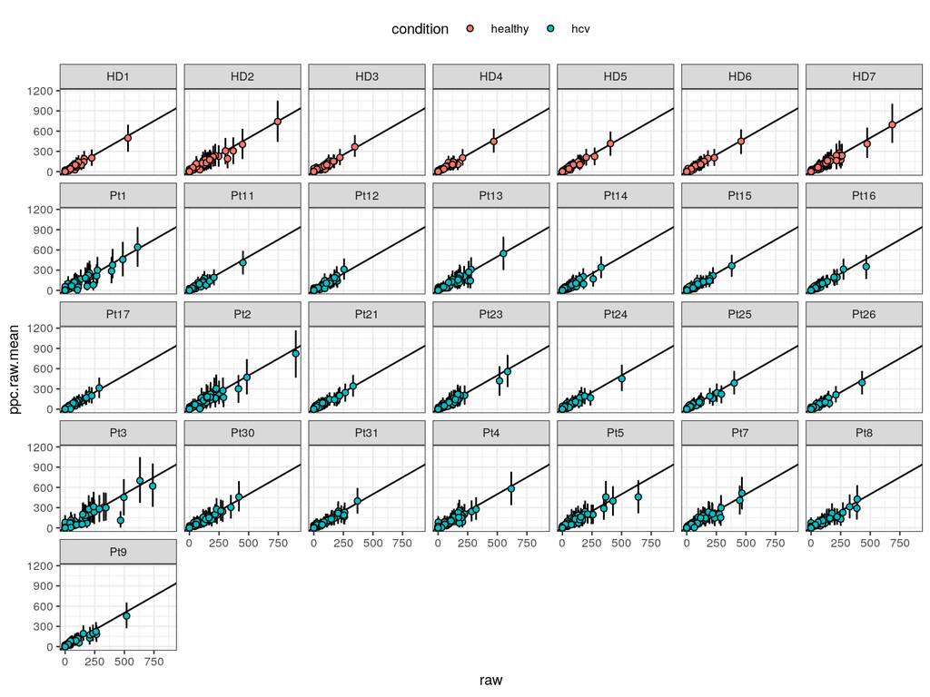

### Errors at a repertoire level

- e[%] = |Yhat[%] - Y[%| or
- e[raw count] = |Yhat[count] - Y[count]|

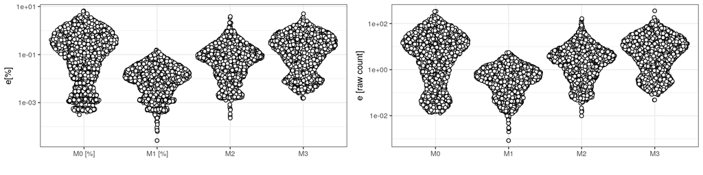

### Errors at a gene level

- raw mean in gene&condition vs ppc mean in gene&condition

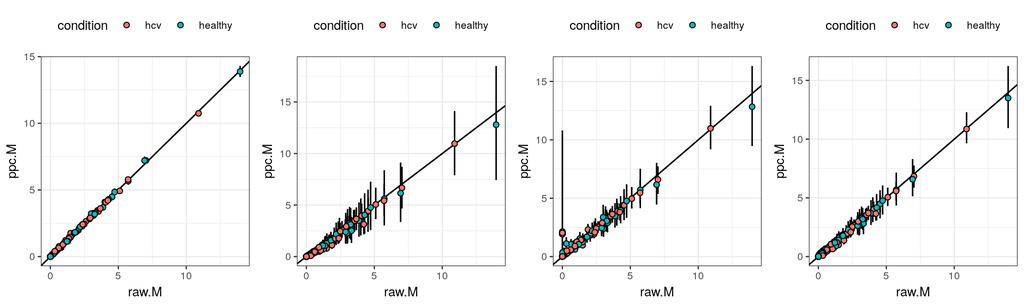